# S371: Lab 5

Lab Instructor: Katya Baldina (baldina@iu.edu)

2023-09-20

# Announcement

TEST 1 OPENED TODAY AT 12.45 PM AND DUE TOMORROW 11.59 PM!

No office hours during the test. If you find anything weird about the test, feel free to email me or Prof. Schultz.

# HW2 Reflection

- Round z-scores to two dicemal places (not zero)
- Show all your work to receive full credit
- quantile() function is not a five number summary function; this is a function that gives you quantiles!!

```r
?quantile
```

*The generic function quantile produces sample quantiles corresponding to the given probabilities.*

# Test 1: Multiple Choice

Canvas system does not allow you to go back to the previous question and change the answer

• You can only re-enter all answers in the multiple-choice section from the beginning

• So try to jot down your answer for multiple-choice questions on a piece of paper in case you need to change any answers

# Test 1: Wording

If the question asks for proportion, it refers to the area under the curve, which corresponds to the numbers here:

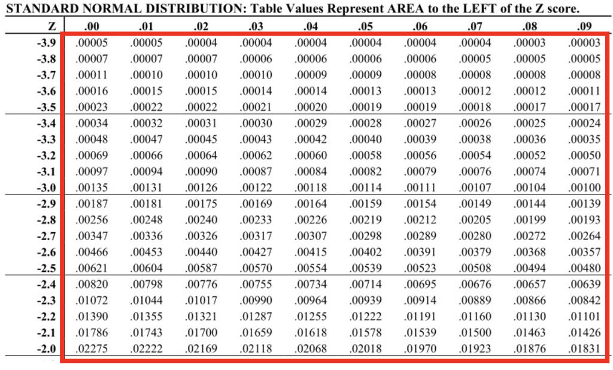

# Test 1: Wording

If question asks you about “how many standard deviations *the certain number* is above the mean”, it means you need to standardize *this number* (convert to z score). If z score is something like 2.5, your answer will be: “*this number* is *2.5 standard deviations above the mean.*”

# Concepts

- Unit of analysis

The *things* or objects described by a set of data

Examples: individual people, families, states, countries, organizations, cars, cats

- Types of variable
  - Quantitative
  - Qualitative

# Concepts

- Mean, Median, Mode
- Five-number summary, quartiles (first, third)
- Standard Deviation

$\sigma = \sqrt{\frac{\sum\limits_{i=1}^{n} \left(x_{i} - \bar{x}\right)^{2}} {n-1}}$

# Concepts

- Distribution
- Mean and median relations (normal distribution)
- Skewness

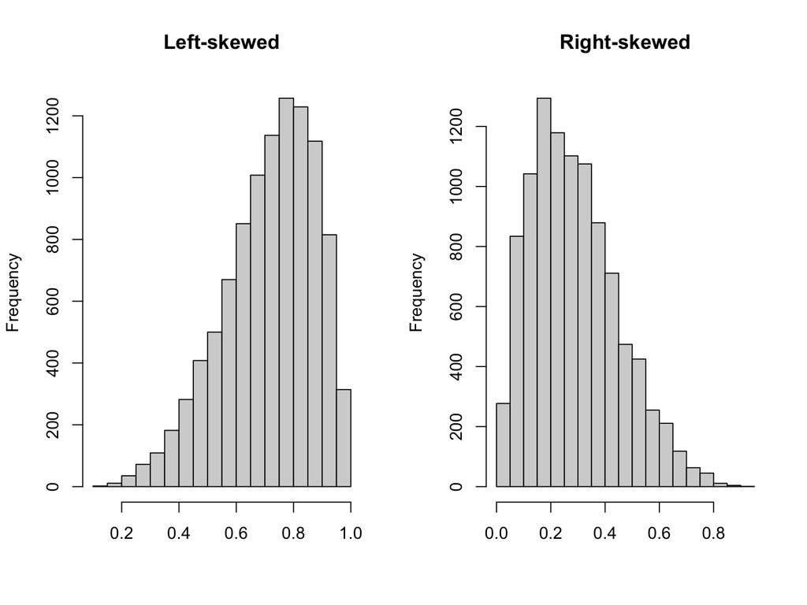

# Concepts

- Histogram, box plot
- Standard Normal Distribution
- Rule of thumb: 68-95-99.7%

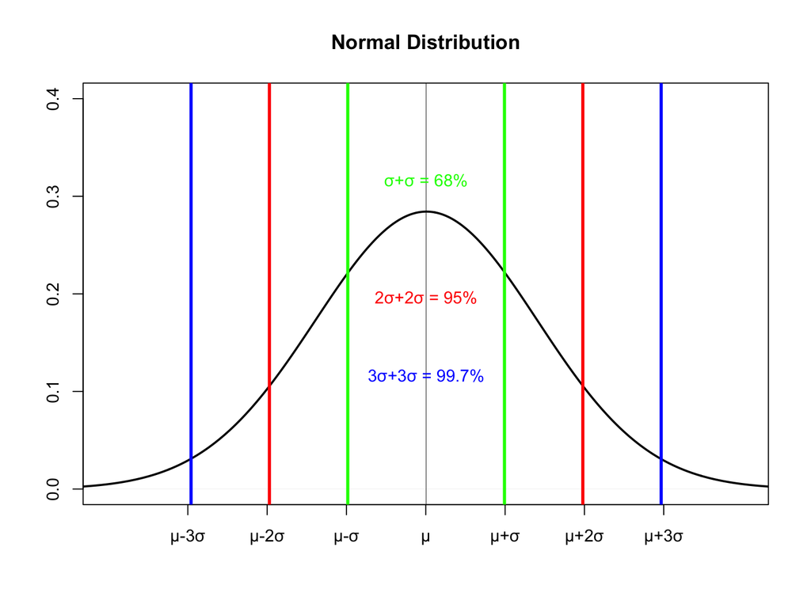

# Z score and Standard Normal Distribution

Z score:

$z = \frac{x-µ}{σ}$

z - standardized score

x - original variable

µ - mean of x

σ - standard deviation of x

Meaning: how many standard deviation is the x value above the mean (positive z score) or below the mean (negative z score)?

Standard deviation becomes the new unit of measurement here

Why convert to z-score?

- allow comparison between different variables/different data
- e.g., compare the z-score of a student in a statistics class and biology class

# Standard Normal Distribution vs. Normal Distribution

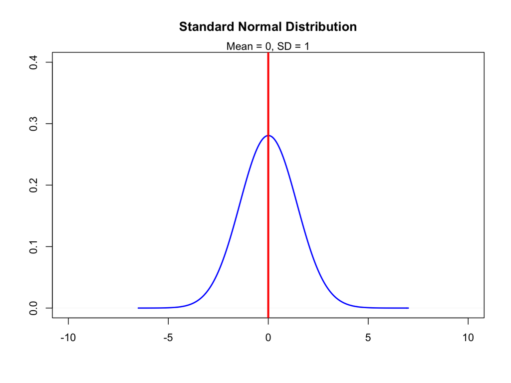

# Standard Normal Distribution vs. Normal Distribution

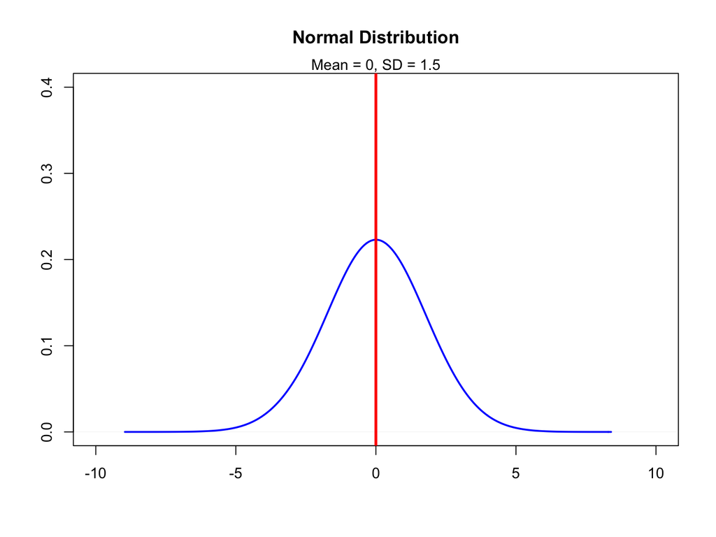

# Standard Normal Distribution vs. Normal Distribution

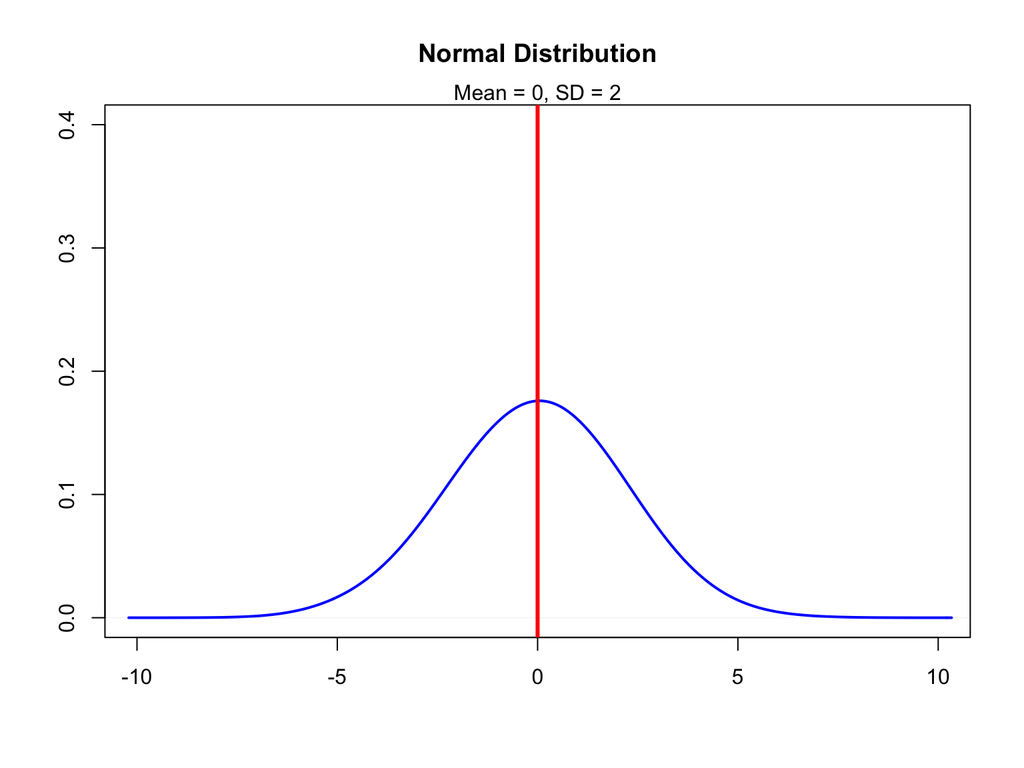

# Standard Normal Distribution vs. Normal Distribution

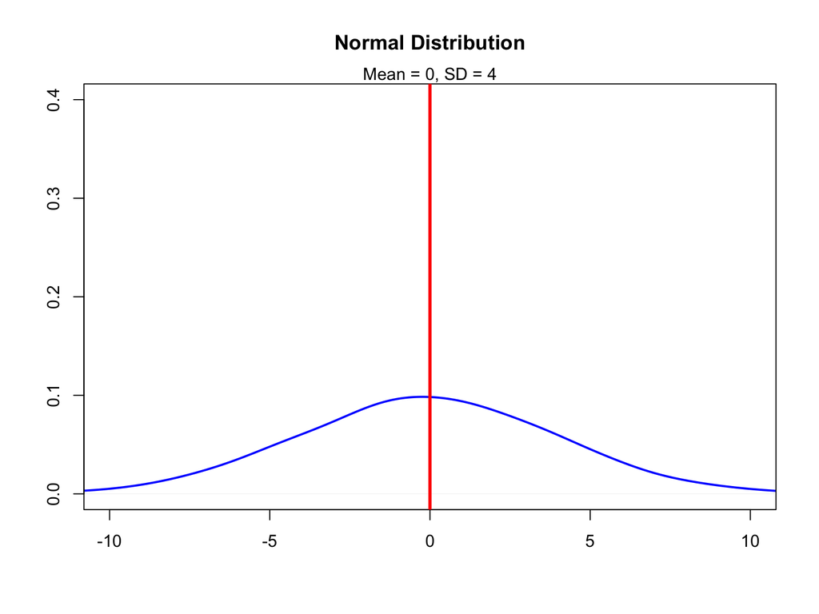

# Standard Normal Distribution vs. Normal Distribution

- What’s the pattern?
  - Higher SD, flatter the curve

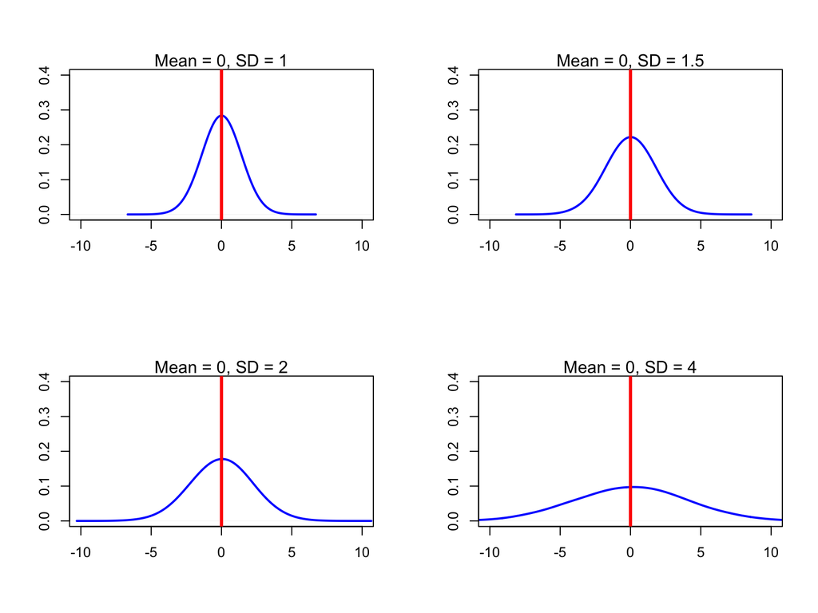

# Standard Normal Distribution vs. Normal Distribution

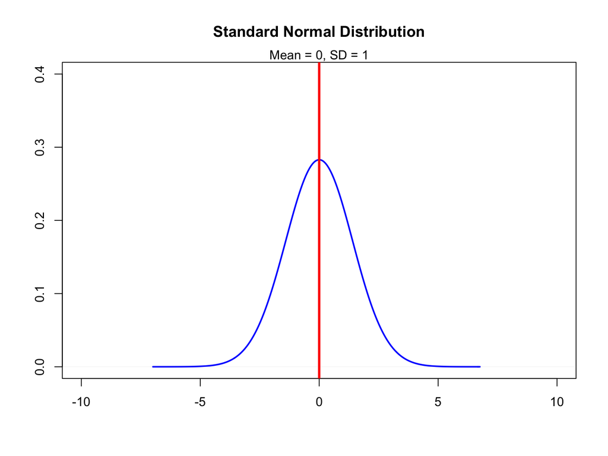

# Standard Normal Distribution vs. Normal Distribution

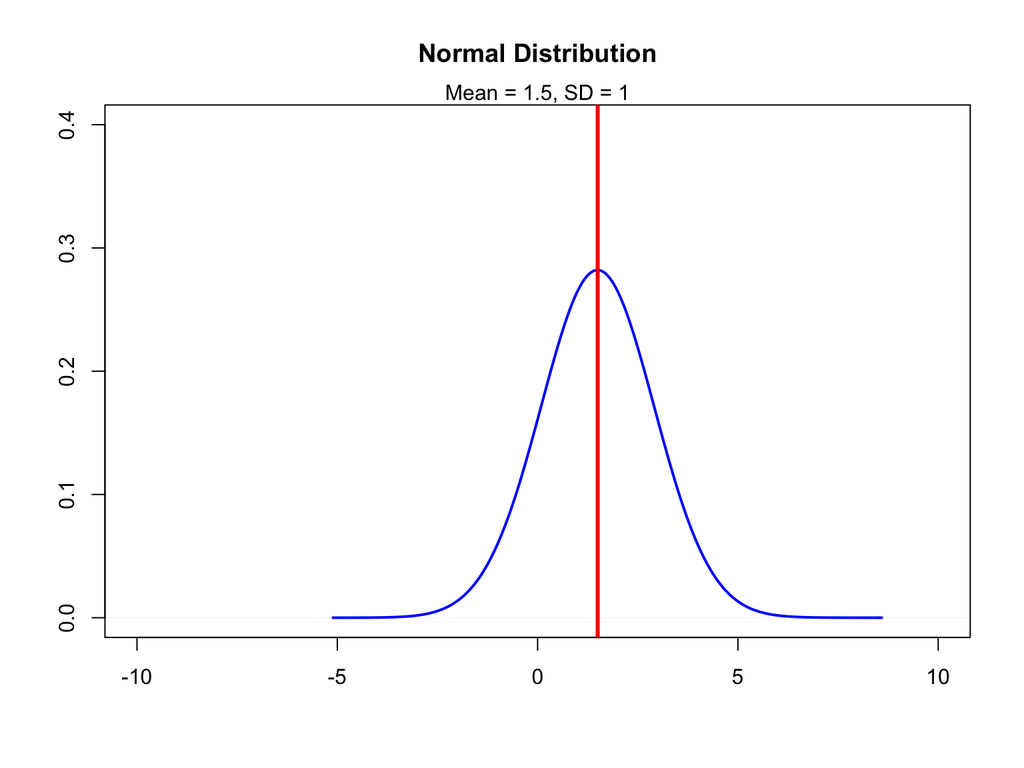

# Standard Normal Distribution vs. Normal Distribution

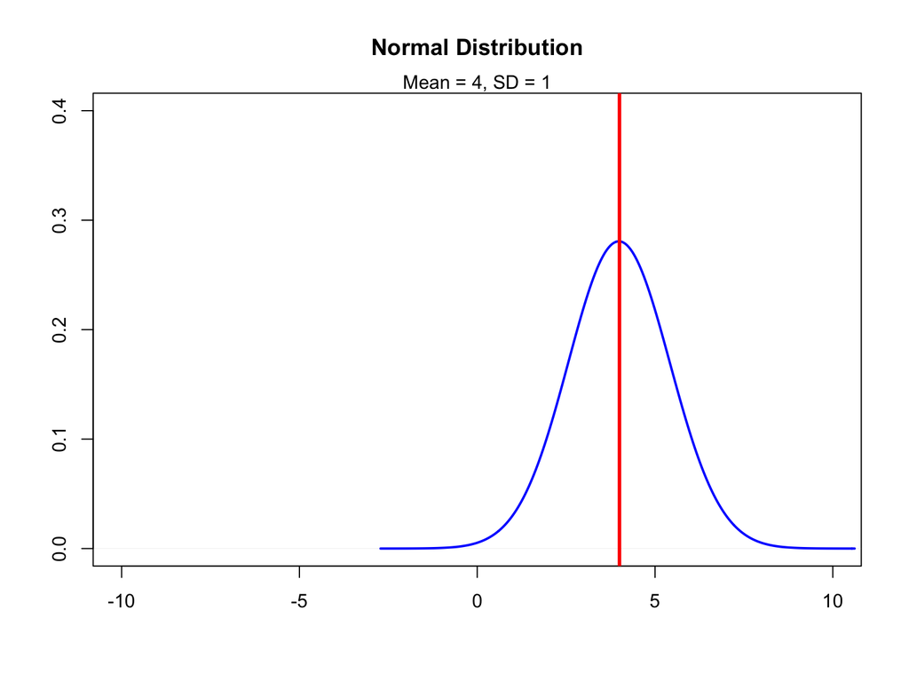

# Standard Normal Distribution vs. Normal Distribution

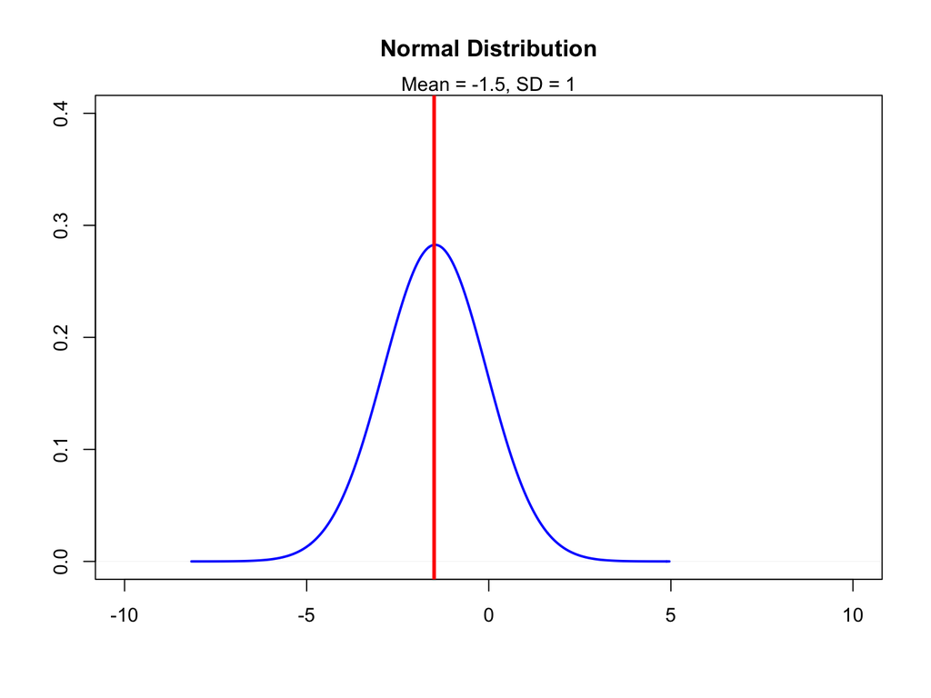

# Standard Normal Distribution vs. Normal Distribution

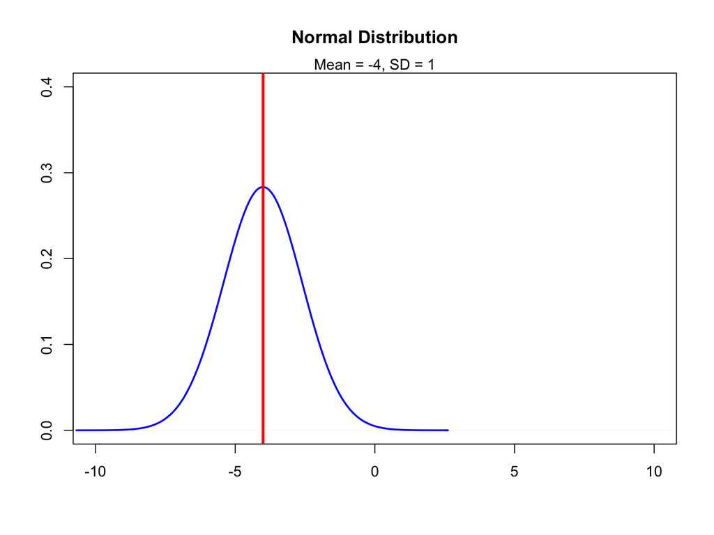

# Standard Normal Distribution vs. Normal Distribution

- What’s the pattern?
  - Different means, different positions of the curve
  - In other words, the curve shifts horizontally without changing its shape

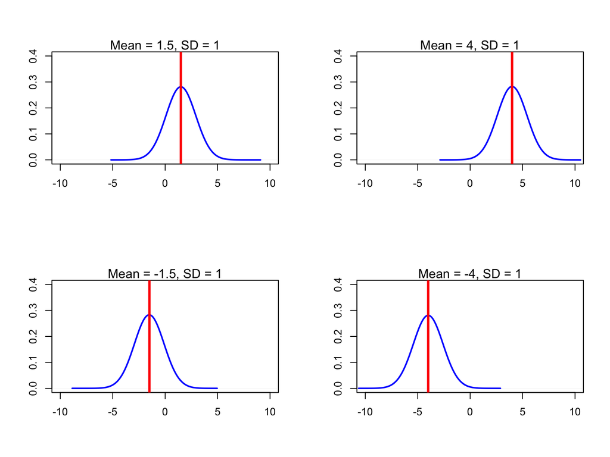

# Z score: Why we need it?

Z-score and the corresponding area under the curve (from left to right) are the properties of a standard normal curve.

We can convert any other normal-like distributions into z-score and these distributions can be converted to standard normal distribution.

Just take the mean and standard deviation from the normal distribution and calculate z-score for each value using this formula:

$z = \frac{x-µ}{σ}$

[figure not shown]

# Standardization

Standardization means that we transform normal distributions to “standard normal distribution”

By converting to z-score, we have a standard/reference for comparison across distributions (across time, populations, or even other variables)

# Z table

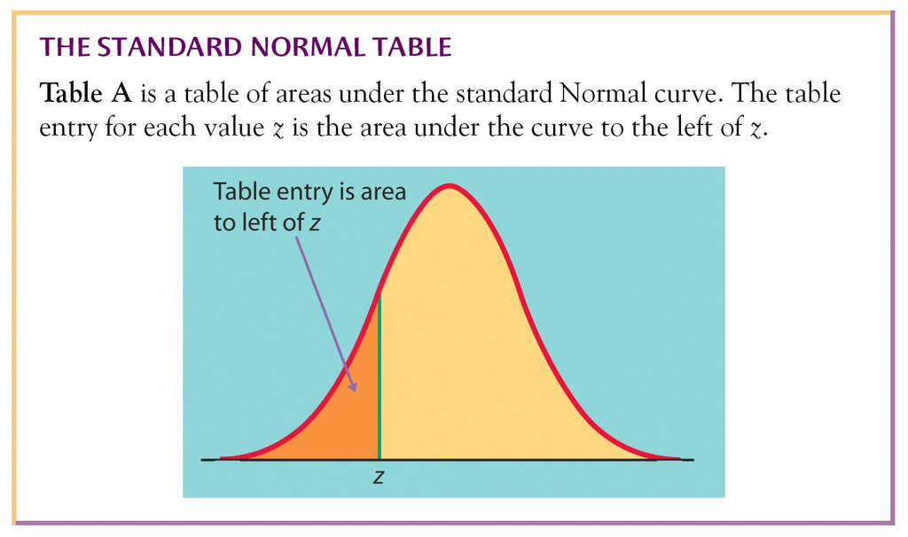

The total area under the standard normal curve is always 1

The area under the standard normal curve is always between 0 and 1

- If your answer (to a question about area under the curve) is larger than 1, you must be wrong
- If your answer (to a question about area under the curve) is smaller than 0, you must be wrong

*Interpretation of z-score: how many standard deviation is the x value above the mean (positive z score) or below the mean (negative z score)?*

| Z | 0.00 | 0.01 | 0.02 | 0.03 | 0.04 | 0.05 | 0.06 | 0.07 | 0.08 | 0.09 |
| --- | --- | --- | --- | --- | --- | --- | --- | --- | --- | --- |
| -0.9 | 0.1841 | 0.1814 | 0.1788 | 0.1762 | 0.1736 | 0.1711 | 0.1685 | 0.1660 | 0.1635 | 0.1611 |
| -0.8 | 0.2119 | 0.2090 | 0.2061 | 0.2033 | 0.2005 | 0.1977 | 0.1949 | 0.1922 | 0.1894 | 0.1867 |
| -0.7 | 0.2420 | 0.2389 | 0.2358 | 0.2327 | 0.2296 | 0.2266 | 0.2236 | 0.2206 | 0.2177 | 0.2148 |
| -0.6 | 0.2743 | 0.2709 | 0.2676 | 0.2643 | 0.2611 | 0.2578 | 0.2546 | 0.2514 | 0.2483 | 0.2451 |

# Example 1

How much is blue shaded area?

or

What is $P(z<-0.85)$?

*Read as “what is the probability of z less than -0.85”*

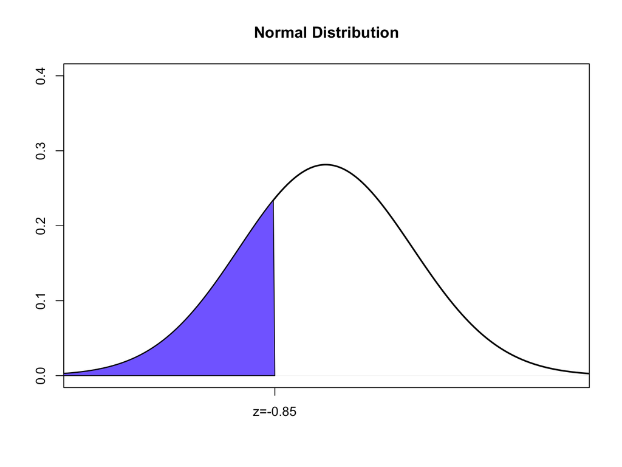

| Z | 0.00 | 0.01 | 0.02 | 0.03 | 0.04 | 0.05 | 0.06 | 0.07 | 0.08 | 0.09 |
| --- | --- | --- | --- | --- | --- | --- | --- | --- | --- | --- |
| -0.9 | 0.1840601 | 0.1814113 | 0.1787864 | 0.1761855 | 0.1736088 | 0.1710561 | 0.1685276 | 0.1660232 | 0.1635431 | 0.1610871 |
| -0.8 | 0.2118554 | 0.2089701 | 0.2061081 | 0.2032694 | 0.2004542 | 0.1976625 | 0.1948945 | 0.1921502 | 0.1894297 | 0.1867329 |
| -0.7 | 0.2419637 | 0.2388521 | 0.2357625 | 0.2326951 | 0.2296500 | 0.2266274 | 0.2236273 | 0.2206499 | 0.2176954 | 0.2147639 |
| -0.6 | 0.2742531 | 0.2709309 | 0.2676289 | 0.2643473 | 0.2610863 | 0.2578461 | 0.2546269 | 0.2514289 | 0.2482522 | 0.2450971 |

# Example 2

What is $P(z<0.34)$?

*Read as “what is the probability of z less than 0.34”*

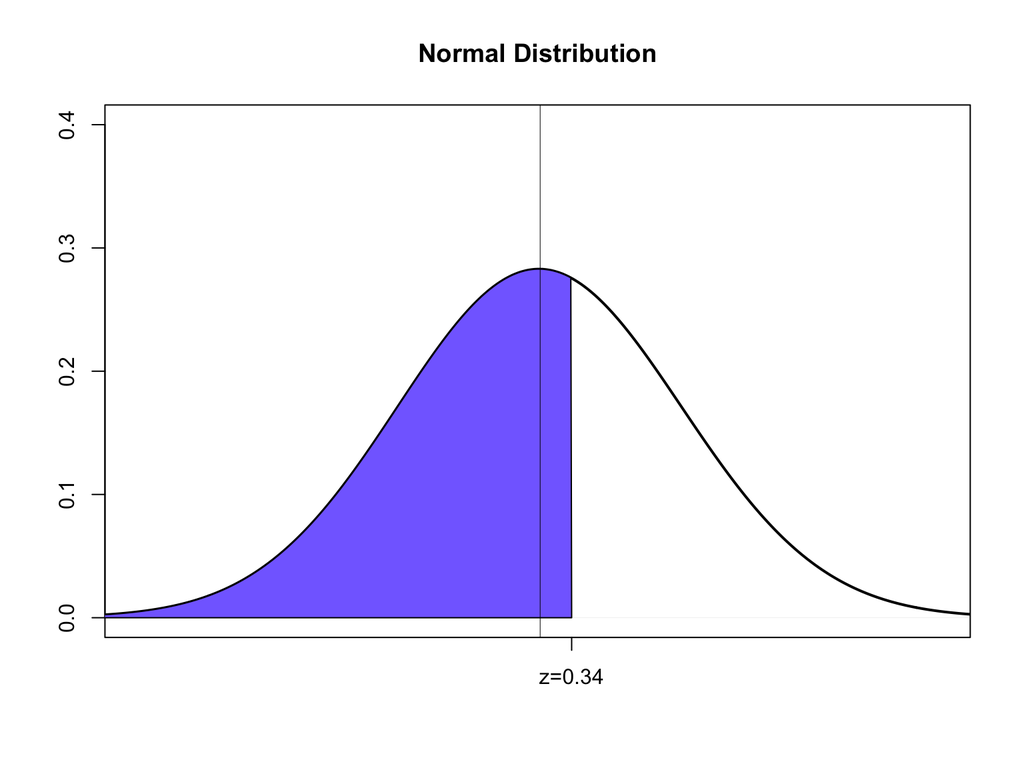

| Z | 0.00 | 0.01 | 0.02 | 0.03 | 0.04 | 0.05 | 0.06 | 0.07 | 0.08 | 0.09 |
| --- | --- | --- | --- | --- | --- | --- | --- | --- | --- | --- |
| 0.2 | 0.5792597 | 0.5831662 | 0.5870644 | 0.5909541 | 0.5948349 | 0.5987063 | 0.6025681 | 0.6064199 | 0.6102612 | 0.6140919 |
| 0.3 | 0.6179114 | 0.6217195 | 0.6255158 | 0.6293000 | 0.6330717 | 0.6368307 | 0.6405764 | 0.6443088 | 0.6480273 | 0.6517317 |
| 0.4 | 0.6554217 | 0.6590970 | 0.6627573 | 0.6664022 | 0.6700314 | 0.6736448 | 0.6772419 | 0.6808225 | 0.6843863 | 0.6879331 |

# Example 3

What is $P(z<2.37)$?

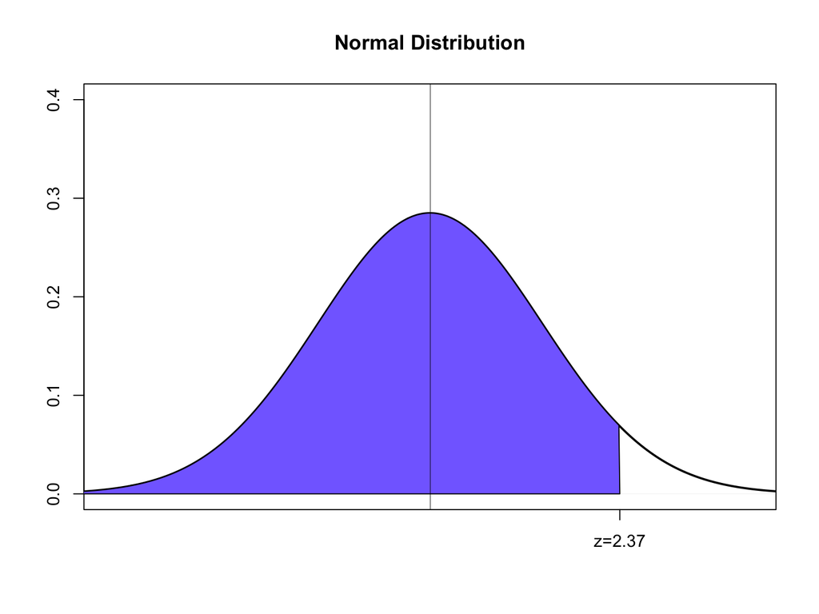

| Z | 0.00 | 0.01 | 0.02 | 0.03 | 0.04 | 0.05 | 0.06 | 0.07 | 0.08 | 0.09 |
| --- | --- | --- | --- | --- | --- | --- | --- | --- | --- | --- |
| 2.2 | 0.9860966 | 0.9864474 | 0.9867906 | 0.9871263 | 0.9874545 | 0.9877755 | 0.9880894 | 0.9883962 | 0.9886962 | 0.9889893 |
| 2.3 | 0.9892759 | 0.9895559 | 0.9898296 | 0.9900969 | 0.9903581 | 0.9906133 | 0.9908625 | 0.9911060 | 0.9913437 | 0.9915758 |
| 2.4 | 0.9918025 | 0.9920237 | 0.9922397 | 0.9924506 | 0.9926564 | 0.9928572 | 0.9930531 | 0.9932443 | 0.9934309 | 0.9936128 |

# Challenging Example #1

What is $P(z>1.24)$?

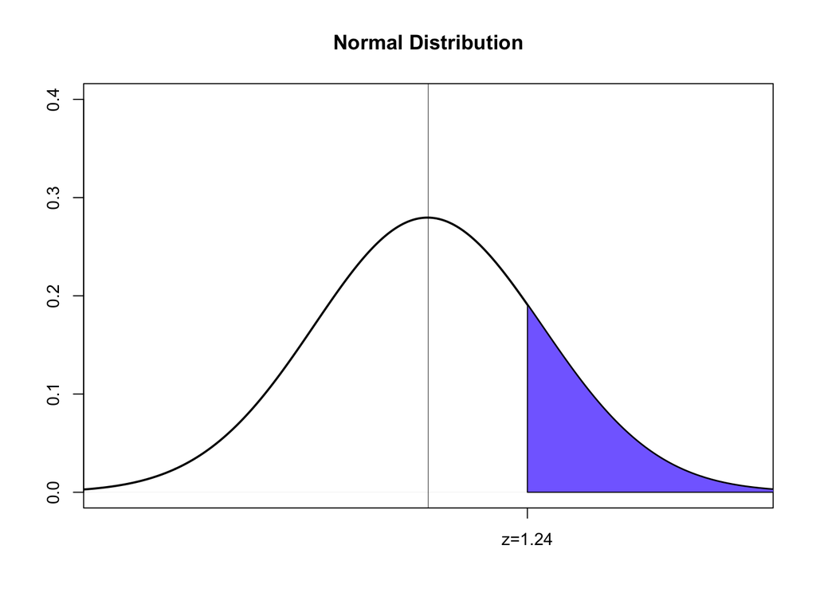

# Challenging Example #1

Method 1:

1. Look at the area to the left (light blue): P(z<1.24)=0.8925
2. P(z>1.24) = 1-P(z<1.24) = 1-0.8925

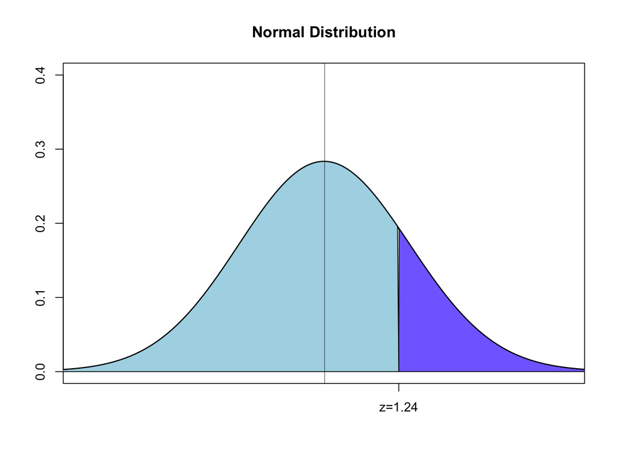

| Z | 0.00 | 0.01 | 0.02 | 0.03 | 0.04 | 0.05 | 0.06 | 0.07 | 0.08 | 0.09 |
| --- | --- | --- | --- | --- | --- | --- | --- | --- | --- | --- |
| 1.1 | 0.8643339 | 0.8665005 | 0.8686431 | 0.8707619 | 0.8728568 | 0.8749281 | 0.8769756 | 0.8789995 | 0.8809999 | 0.8829768 |
| 1.2 | 0.8849303 | 0.8868606 | 0.8887676 | 0.8906514 | 0.8925123 | 0.8943502 | 0.8961653 | 0.8979577 | 0.8997274 | 0.9014747 |
| 1.3 | 0.9031995 | 0.9049021 | 0.9065825 | 0.9082409 | 0.9098773 | 0.9114920 | 0.9130850 | 0.9146565 | 0.9162067 | 0.9177356 |

# Area under the curve to the right:

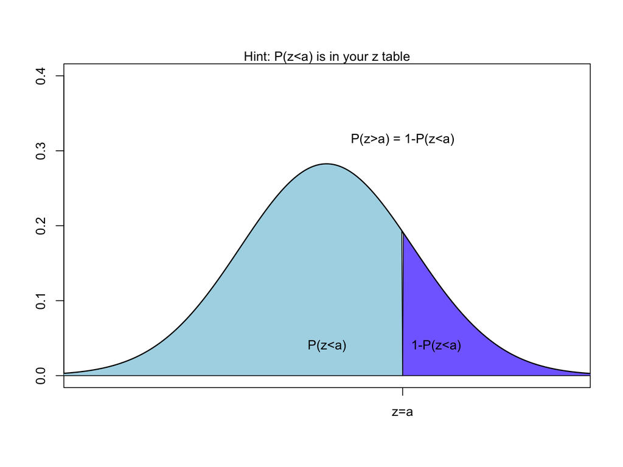

# Method #2: using the symmetric property

Based on symmetry, the area on the left should be the same as the area on the right.

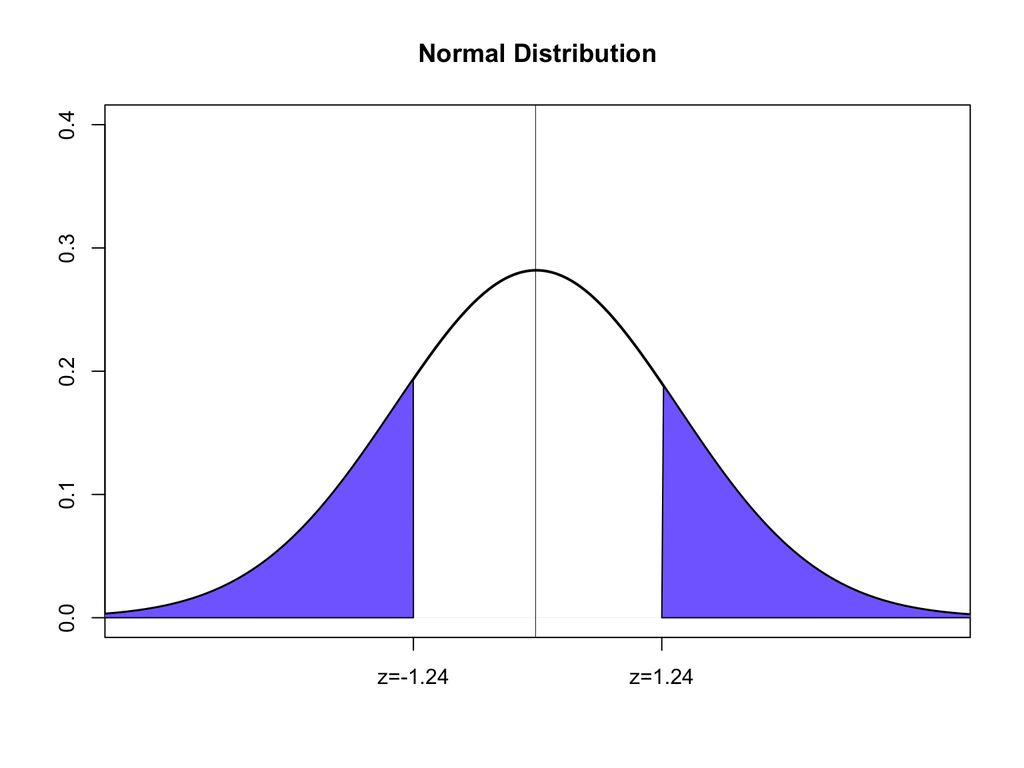

Therefore, all you need to do is to look up the z table for P(z<-1.24):

| Z | 0.00 | 0.01 | 0.02 | 0.03 | 0.04 | 0.05 | 0.06 | 0.07 | 0.08 | 0.09 |
| --- | --- | --- | --- | --- | --- | --- | --- | --- | --- | --- |
| -1.3 | 0.0968005 | 0.0950979 | 0.0934175 | 0.0917591 | 0.0901227 | 0.0885080 | 0.0869150 | 0.0853435 | 0.0837933 | 0.0822644 |
| -1.2 | 0.1150697 | 0.1131394 | 0.1112324 | 0.1093486 | 0.1074877 | 0.1056498 | 0.1038347 | 0.1020423 | 0.1002726 | 0.0985253 |
| -1.1 | 0.1356661 | 0.1334995 | 0.1313569 | 0.1292381 | 0.1271432 | 0.1250719 | 0.1230244 | 0.1210005 | 0.1190001 | 0.1170232 |